# Favoured Model: Mixed effects ordinal regression (stacked data)

## Model

Here are all key variables in model. It’s not really the way to go, since you should do incremental model comparisons and then model selection to pick best. But for now, this is good enough to illustrate the main findings.

*Note* I’ve used a rolling average for “EU a good thing” for the years 2015:2017 that were in the spreadsheet.

```r
# Fit model
m1 = clmm(Tone ~ level * dim + net_bal_pc + goodMu + equi17 + selfrule + vis4 + words + year2 + sourceFormat + (1|country) +  (1|site),
          Hess = TRUE,
          data = df,
          threshold = "flexible")
```

### Summary

```
## Cumulative Link Mixed Model fitted with the Laplace approximation
##
## formula: Tone ~ level * dim + net_bal_pc + goodMu + equi17 + selfrule +
##     vis4 + words + year2 + sourceFormat + (1 | country) + (1 |      site)
## data:    df
##
##  link  threshold nobs logLik  AIC     niter      max.grad cond.H
##  logit flexible  984  -801.70 1637.39 1485(4654) 9.95e-03 5.7e+06
##
## Random effects:
##  Groups  Name        Variance Std.Dev.
##  site    (Intercept) 0.7519   0.8671
##  country (Intercept) 0.1877   0.4333
## Number of groups:  site 227,  country 8
##
## Coefficients:
##                            Estimate Std. Error z value Pr(>|z|)
## levelNational             -0.695467   0.270421  -2.572 0.010117 *
## dimPolitics               -3.386004   0.328265 -10.315  < 2e-16 ***
## net_bal_pc                 0.001756   0.002278   0.771 0.440772
## goodMu                    -1.403749   1.883248  -0.745 0.456038
## equi17                     0.394066   0.407845   0.966 0.333936
## selfrule                   0.018089   0.049425   0.366 0.714378
## vis4.L                    -0.018830   0.150132  -0.125 0.900187
## vis4.Q                     0.234973   0.129018   1.821 0.068569 .
## words500-1000             -0.488476   0.169224  -2.887 0.003895 **
## words+1000                -1.109940   0.289015  -3.840 0.000123 ***
## year2                     -0.137101   0.107446  -1.276 0.201955
## sourceFormatOnline only    0.111016   0.221805   0.501 0.616714
## levelNational:dimPolitics  0.946272   0.355492   2.662 0.007771 **
## ---
## Signif. codes:  0 '***' 0.001 '**' 0.01 '*' 0.05 '.' 0.1 ' ' 1
##
## Threshold coefficients:
##                  Estimate Std. Error z value
## Negative|Neutral  -4.4090     0.9869  -4.467
## Neutral|Positive  -2.3213     0.9756  -2.379
## (1 observation deleted due to missingness)
```

### Regression in tidy output

|  | Dependent Variable: Europeanization |
| --- | --- |
| Level:National | -0.695 * (-2.572) |
| Frame:Politics | -3.386 *** (-10.315) |
| Net balance p.c. | 0.002 (0.771) |
| EU good thing (average) | -1.404 (-0.745) |
| Quality governance | 0.394 (0.966) |
| Level self rule | 0.018 (0.366) |
| Visibility: very low \| low/medium | -0.019 (-0.125) |
| Visibility: low/medium \| high | 0.235 (1.821) |
| Word length (500:1000) | -0.488 ** (-2.887) |
| Word length (+1000) | -1.110 *** (-3.840) |
| Year | -0.137 (-1.276) |
| Type:Web native | 0.111 (0.501) |
| Level * Frames | 0.946 ** (2.662) |
| Mixed effects ordinal regression (z values in brackets). Significant coefficients <0.05 in bold. P-value signficance levels: *** p < 0.001; ** p < 0.01; * p < 0.05. |  |

So in this model only 3 variables are signficant, Frames, Level and word length of story. The latter is unimportant obviously.

### Plot main regression

The interaction Frame by Level is signficant, so best to plot it. In these graphs I’ve used standard errors, rather than confidence intervals to see which bits are driving the signficant coefficients.

It’s probably clearer now to see the change from an Economics frame to Politics frame for each type of Tone. Basically there are minimal difference regarding Politics between the two levels. It seems to be the Economic frame driving this. The differences can be seen in the Economics frame of the Neutral panel (regional less likely to be Neutral) and Postive panel (regional more likely to be positive).

The first plot is without interaction, the second shows the interaction effect. They’re not huge -but it’s something.

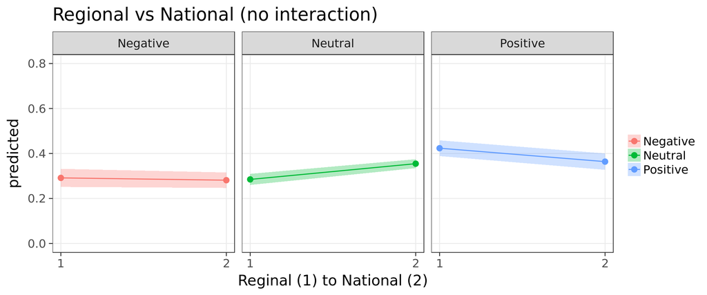

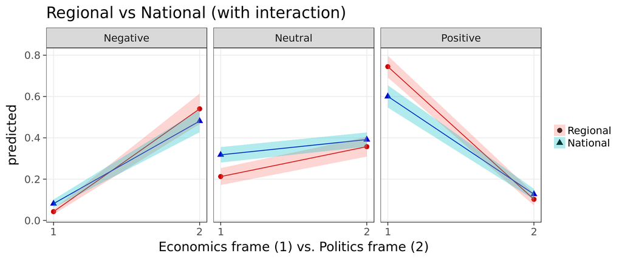

# Annex

Just to check the word length plot. Here we can see shorter stories are more likely to be positive. Longer stories are more likely to be negative Tone, esepcially in the Politics frame, and less likely to be Postive in the Economic frame

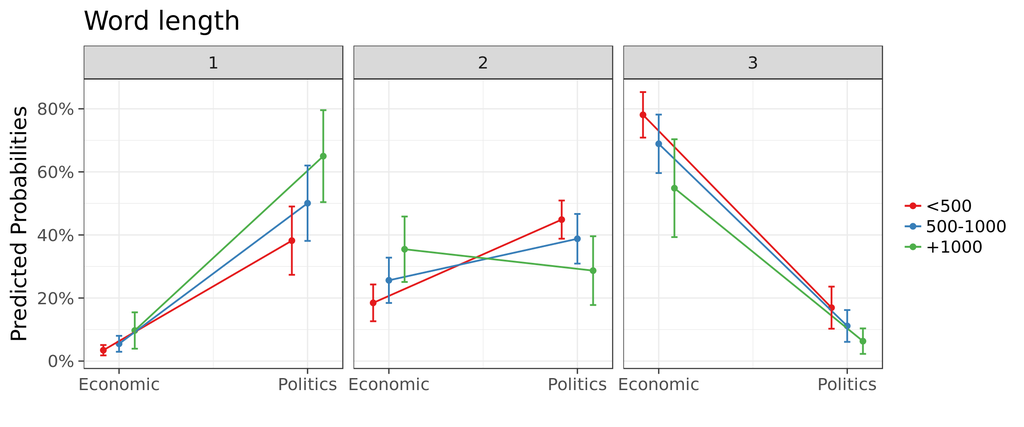